# Nujabes - Feather

2020-02-23 T19:15:14+00:00

[figure not shown]

Light as a feather When I’m floatin through Readin through the daily news Measuring the hurt within the golden rule

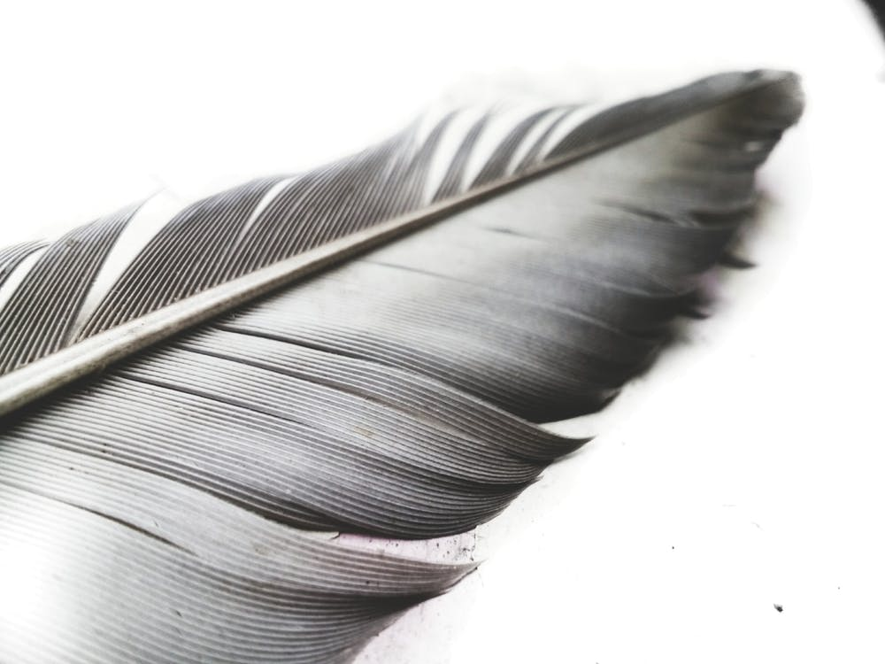

Centimetres of ether I’m heatin the speaker Motivational teacher with words that burn people Seeing the headlines lined with discord It’s either genocide, all the planet in uproar

Never good but rules of paradise are never nice The best laid plan of mice and men are never right I’m just a vagabond with flowers for algernon The average joe who knows what the fuck is goin on It’s the hope of my thoughts that i travelled upon Fly like an arrow of god until I’m gone

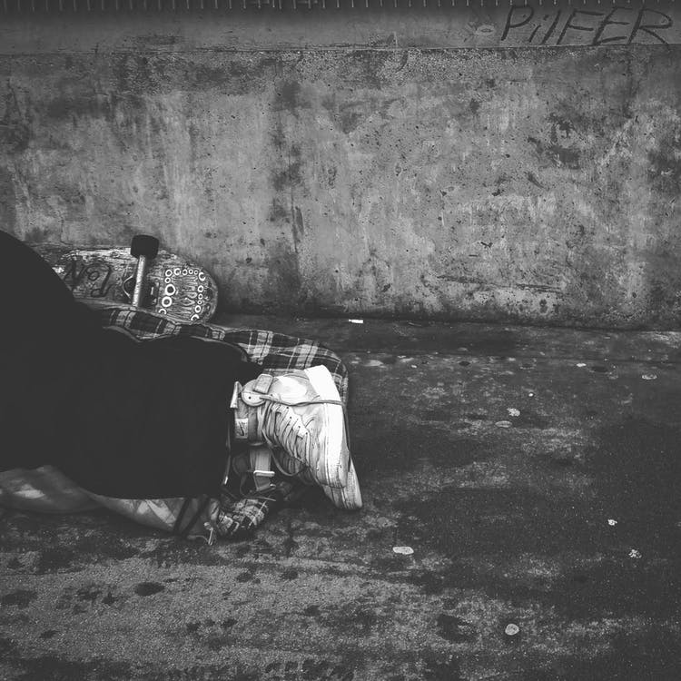

So I’m driftin away like a feather in air Lettin my words take me away from the hurt and despair So I’m keepin it vertical forever elevator Ridin the escalator to the somethin that is greater

So I’m driftin away like a feather in air Lettin my soul take me away from the hurt and despair So I’m keepin it vertical forever elevator Ridin the escalator to the somethin that is greater Taking chances Word tap dancing with wolves In an ice arena out there, deep in the woods of arizona The sun be high, life’s ironic

Aint tryin to be talib when I write Surreal life I paint it vivid habitat crazy insane Watch the propaganda 6 o’clock news that are saying Cultures clash for black folk and white trash They revel in the cyberspace that might crash Dash to millineum a million miles of runnin

[figure not shown]

Ayo take you right back to birth And niggaz wonder why they might wonder why This shit might happen but it does, they go

[figure not shown]

Driftin away like a feather in air Lettin my words take me away from the hurt and despair So i’m keepin it vertical forever elevator Ridin the escalator to the somethin that is greater

So I’m driftin away like a feather in air Lettin my soul take me away from the hurt and despair So I’m keepin it vertical forever elevator Ridin the escalator to the somethin that is greater

Treat you better than me Because that’s the heavenly key To unlock the inner strength Where my essence will be It’s the knowledge of self

Understanding of the things around me That becomes the wisdom that I need Living this life to the best of my ability Channelling energy to my thoughts into your symmetry Remember me because my clothes remain gold

[figure not shown]

I got the gift of gab like them pimps in kangols It never ends I keep it rulin like a cypher The first caveman bringin fire Innovating and higher to blast mistakes I raise the stakes